# Coffe Trend and Recipe

Dimas Aditya

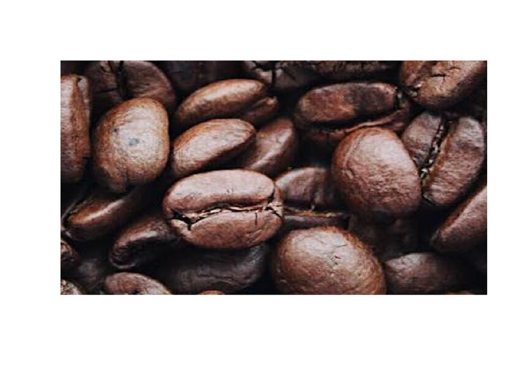

# Introduction

Pada bulan Oktober 2023, James Hoffmann melakukan uji rasa secara langsung dengan sekitar 4.000 orang di AS. Sebulan kemudian, dia merilis data survei untuk uji rasa, setiap peserta dikirimkan empat sampel kopi tanpa label. Survey ini dapat memberikan gambaran gambaran menarik secara statistik untuk itu mari kita buatkan visualisasi statistik yang menarik.

source: https://github.com/rfordatascience/tidytuesday/blob/master/data/2024/2024-05-14/readme.md

### Business Question

*1.Diumur berapa konsumsi coffe tertinggi ?*

*2.Rekomendasi Coffe terbaik ?*

*3.Dimana tempat menikmati Coffe paling favorit ?*

## 1. Data Preparation

### 1.1 Prerequisites

### 1.2 Importing Libraries

```r
# for data wrangling
library(lubridate)
```

```r
library(tidyr)
# visualization
library(ggplot2)
library(dplyr)
library(DT)
library(png)
library(grid)
library(prettydoc)
library(rmarkdown)
```

## 1.3 Importing Dataset

```r
Coffe <- read.csv("data_input/Coffe.csv")
```

## 2. Data Processing

### 2.1 Duplicates

```r
sum(duplicated(Coffe))
```

```
## [1] 0
```

### 2.2 Missing Values

```r
sum(is.na(Coffe))
```

```
## [1] 56764
```

```r
Coffe1 <- subset(Coffe, select = c(age, where_drink, cups, favorite, additions, style, strength, roast_level, caffeine))
```

```r
Coffe1[Coffe1 == ""] <- NA
```

Mari kita chek kembali data yang sudah kita seleksi

```r
colSums(is.na(x = Coffe1))
```

```
##         age where_drink        cups    favorite   additions       style
##          31          70          93          62          83          84
##    strength roast_level    caffeine
##         126         102         125
```

```r
colSums(is.na(x = Coffe1))
```

```
##         age where_drink        cups    favorite   additions       style
##          31          70          93          62          83          84
##    strength roast_level    caffeine
##         126         102         125
```

```r
Coffe2 <- Coffe1 %>%
  drop_na()
```

### 2.3 Data Types

Untuk mempermudah pengolahannya mari kita rubah dulu seluruh data character menjadi factor dalam kolom yang sudah di seleksi

```r
summary(Coffe2)
```

```
##      age            where_drink            cups             favorite
##  Length:3811        Length:3811        Length:3811        Length:3811
##  Class :character   Class :character   Class :character   Class :character
##  Mode  :character   Mode  :character   Mode  :character   Mode  :character
##   additions            style             strength         roast_level
##  Length:3811        Length:3811        Length:3811        Length:3811
##  Class :character   Class :character   Class :character   Class :character
##  Mode  :character   Mode  :character   Mode  :character   Mode  :character
##    caffeine
##  Length:3811
##  Class :character
##  Mode  :character
```

```r
str(Coffe2)
```

```
## 'data.frame':    3811 obs. of  9 variables:
##  $ age        : chr  "<18 years old" "25-34 years old" "<18 years old" ">65 years old" ...
##  $ where_drink: chr  "On the go, At a cafe, At home, At the office" "At the office" "At home, At the office, At a cafe" "At the office, At a cafe" ...
##  $ cups       : chr  "2" "1" "3" "3" ...
##  $ favorite   : chr  "Other" "Pourover" "Pourover" "Cortado" ...
##  $ additions  : chr  "Milk, dairy alternative, or coffee creamer, Sugar or sweetener, Flavor syrup" "No - just black" "No - just black, Milk, dairy alternative, or coffee creamer" "No - just black" ...
##  $ style      : chr  "Full Bodied" "Fruity" "Bright" "Fruity" ...
##  $ strength   : chr  "Somewhat light" "Somewhat strong" "Medium" "Somewhat strong" ...
##  $ roast_level: chr  "Light" "Light" "Light" "Blonde" ...
##  $ caffeine   : chr  "Full caffeine" "Full caffeine" "Full caffeine" "Full caffeine" ...
```

## 3. Exploratory Data Analysis

```r
Coffe3 <- Coffe2 %>%
  mutate(across(where(is.character), as.factor))
```

### 3.1 Umur penikmat coffe tertinggi

```r
oage <- Coffe3 %>%
group_by(age) %>%
  summarise(total = n()) %>%
  arrange(desc(total))
oage
```

```
## # A tibble: 7 × 2
##   age             total
##   <fct>           <int>
## 1 25-34 years old  1900
## 2 35-44 years old   914
## 3 18-24 years old   424
## 4 45-54 years old   291
## 5 55-64 years old   176
## 6 >65 years old      89
## 7 <18 years old      17
```

### 3.2 Melihat resep terbaik untuk semua umur

```r
allrecipe <- Coffe3 %>%
group_by(favorite, style, additions, strength, roast_level, caffeine) %>%
  summarise(count = n()) %>%
  arrange(desc(count)) %>%
  ungroup() %>% head(5)
```

[output not shown]

```r
allrecipe
```

```
## # A tibble: 5 × 7
##   favorite style  additions       strength        roast_level caffeine     count
##   <fct>    <fct>  <fct>           <fct>           <fct>       <fct>        <int>
## 1 Pourover Fruity No - just black Medium          Light       Full caffei…   123
## 2 Pourover Fruity No - just black Somewhat strong Light       Full caffei…   118
## 3 Pourover Juicy  No - just black Medium          Light       Full caffei…    43
## 4 Pourover Juicy  No - just black Somewhat strong Light       Full caffei…    42
## 5 Pourover Bright No - just black Somewhat strong Light       Full caffei…    34
```

Mari kita buatkan resep terbaik untuk masing masing umur melakukan agregasi

```r
age <- Coffe3 %>%
group_by(age, favorite, style, additions, strength, roast_level, caffeine) %>%
  summarise(count = n()) %>%
  arrange(desc(count)) %>%
  ungroup()
```

[output not shown]

```r
age
```

```
## # A tibble: 2,521 × 8
##    age             favorite style  additions strength roast_level caffeine count
##    <fct>           <fct>    <fct>  <fct>     <fct>    <fct>       <fct>    <int>
##  1 25-34 years old Pourover Fruity No - jus… Medium   Light       Full ca…    72
##  2 25-34 years old Pourover Fruity No - jus… Somewha… Light       Full ca…    63
##  3 35-44 years old Pourover Fruity No - jus… Medium   Light       Full ca…    36
##  4 25-34 years old Pourover Juicy  No - jus… Somewha… Light       Full ca…    28
##  5 35-44 years old Pourover Fruity No - jus… Somewha… Light       Full ca…    28
##  6 25-34 years old Pourover Juicy  No - jus… Medium   Light       Full ca…    18
##  7 25-34 years old Pourover Floral No - jus… Somewha… Light       Full ca…    17
##  8 18-24 years old Pourover Fruity No - jus… Somewha… Light       Full ca…    15
##  9 25-34 years old Pourover Bright No - jus… Medium   Light       Full ca…    15
## 10 25-34 years old Pourover Bright No - jus… Somewha… Light       Full ca…    15
## # ℹ 2,511 more rows
```

Mengelompokan data berdasarkan umur

```r
agerecipe<- age %>%
  group_by(age) %>%
  slice_max(order_by = count, n = 1) %>%
  arrange(desc(count)) %>%
  ungroup() %>% head(5)
agerecipe
```

```
## # A tibble: 5 × 8
##   age             favorite style  additions  strength roast_level caffeine count
##   <fct>           <fct>    <fct>  <fct>      <fct>    <fct>       <fct>    <int>
## 1 25-34 years old Pourover Fruity No - just… Medium   Light       Full ca…    72
## 2 35-44 years old Pourover Fruity No - just… Medium   Light       Full ca…    36
## 3 18-24 years old Pourover Fruity No - just… Somewha… Light       Full ca…    15
## 4 45-54 years old Pourover Fruity No - just… Somewha… Light       Full ca…     6
## 5 55-64 years old Pourover Fruity No - just… Somewha… Light       Full ca…     6
```

Merubah tampilan berdasarkan jumlah peminat dan resep

```r
x <- data.frame(
  age = c("25-34 years old", "35-44 years old", "18-24 years old", "45-54 years old", "55-64 years old"),
  favorite = c("Pourover", "Pourover", "Pourover", "Pourover", "Pourover"),
  style = c("Fruity", "Fruity", "Fruity", "Fruity", "Fruity"),
  additions = c("No - just black", "No - just black", "No - just black", "No - just black", "No - just black"),
  strength = c("Medium", "Medium", "Somewhat strong", "Somewhat strong", "Somewhat strong"),
  roast_level = c("Light", "Light", "Light", "Light", "Light"),
  caffeine = c("Full caffeine", "Full caffeine", "Full caffeine", "Full caffeine", "Full caffeine"),
  count = c(72, 36, 15, 6, 6)
)

# Menggabungkan nilai dari kolom-kolom kecuali age dan count menjadi satu kolom 'details'
age_united <- x %>%
  unite("recipe", -c(age, count), sep = ", ")
age_united
```

```
##               age
## 1 25-34 years old
## 2 35-44 years old
## 3 18-24 years old
## 4 45-54 years old
## 5 55-64 years old
##                                                                     recipe
## 1          Pourover, Fruity, No - just black, Medium, Light, Full caffeine
## 2          Pourover, Fruity, No - just black, Medium, Light, Full caffeine
## 3 Pourover, Fruity, No - just black, Somewhat strong, Light, Full caffeine
## 4 Pourover, Fruity, No - just black, Somewhat strong, Light, Full caffeine
## 5 Pourover, Fruity, No - just black, Somewhat strong, Light, Full caffeine
##   count
## 1    72
## 2    36
## 3    15
## 4     6
## 5     6
```

### 3.3 Melihat data berdasarkan tempat terbaik

Mari kita lihat kembali data Coffe 3

```r
Coffe3 %>%  head(5)
```

```
##               age                                  where_drink cups
## 1   <18 years old On the go, At a cafe, At home, At the office    2
## 2 25-34 years old                                At the office    1
## 3   <18 years old            At home, At the office, At a cafe    3
## 4   >65 years old                     At the office, At a cafe    3
## 5 25-34 years old            At home, At the office, On the go    1
##              favorite
## 1               Other
## 2            Pourover
## 3            Pourover
## 4             Cortado
## 5 Regular drip coffee
##                                                                      additions
## 1 Milk, dairy alternative, or coffee creamer, Sugar or sweetener, Flavor syrup
## 2                                                              No - just black
## 3                  No - just black, Milk, dairy alternative, or coffee creamer
## 4                                                              No - just black
## 5               Milk, dairy alternative, or coffee creamer, Sugar or sweetener
##         style        strength roast_level      caffeine
## 1 Full Bodied  Somewhat light       Light Full caffeine
## 2      Fruity Somewhat strong       Light Full caffeine
## 3      Bright          Medium       Light Full caffeine
## 4      Fruity Somewhat strong      Blonde Full caffeine
## 5       Sweet Somewhat strong      Medium Full caffeine
```

Untuk menikmati coffe lebih baik selain resep terkadang tempat ikut mempengaruhi kenikmatan tersebut.Mari kita lihat dalam bentuk boxplot untuk melihat susunan datanya

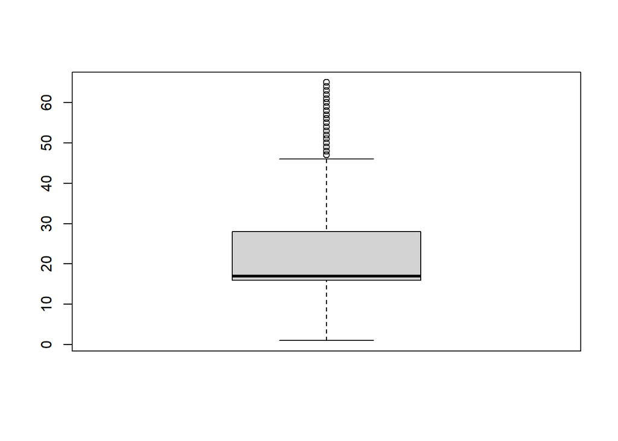

```r
boxplot(Coffe3$where_drink)
```

Dari bentuk boxplot diatas terdapat banyak sekali variasi datanya, mari kita perbaiki untuk mendapatkan data yang lebih relevan

```r
data <- c(
  "At a cafe                           63",
  "At a cafe, At home            80",
  "At a cafe, At home, At the office            16",
  "At a cafe, At home, At the office, On the go                5",
  "At a cafe, At home, On the go            14",
  "At a cafe, At home, On the go, At the office            6",
  "At a cafe, At the office            4",
  "At a cafe, At the office, At home            18",
  "At a cafe, At the office, At home, On the go            3",
  "At a cafe, At the office, On the go            1",
  "At a cafe, On the go, At home            6",
  "At a cafe, On the go, At home, At the office            3",
  "At a cafe, On the go, At the office            1",
  "At home            1558",
  "At home, At a cafe            405",
  "At home, At a cafe, At the office            47",
  "At home, At a cafe, At the office, On the go            8",
  "At home, At a cafe, On the go            35",
  "At home, At a cafe, On the go, At the office            20",
  "At home, At the office            389",
  "At home, At the office, At a cafe            76",
  "At home, At the office, At a cafe, On the go            18",
  "At home, At the office, None of these            1",
  "At home, At the office, On the go            45",
  "At home, At the office, On the go, At a cafe            23",
  "At home, None of these            1",
  "At home, On the go            118",
  "At home, On the go, At a cafe            33",
  "At home, On the go, At a cafe, At the office            14",
  "At home, On the go, At the office            40",
  "At home, On the go, None of these            1",
  "At the office            135",
  "At the office, At a cafe            10",
  "At the office, At a cafe, At home            18",
  "At the office, At a cafe, At home, On the go            8",
  "At the office, At a cafe, On the go            2",
  "At the office, At home, At a cafe            60",
  "At the office, At home, At a cafe, On the go            12",
  "At the office, At home, On the go            29",
  "At the office, None of these            1",
  "At the office, On the go            12",
  "At the office, On the go, At a cafe            3",
  "At the office, On the go, At home            13",
  "None of these            29",
  "None of these, At a cafe            1",
  "On the go            31",
  "On the go, At a cafe            6",
  "On the go, At a cafe, At home            7",
  "On the go, At a cafe, At home, At the office            7",
  "On the go, At a cafe, At the office            2",
  "On the go, At a cafe, At the office, At home            34",
  "On the go, At home, At a cafe            15",
  "On the go, At home, At a cafe, At the office            5",
  "On the go, At home, At the office            11",
  "On the go, At home, At the office, At a cafe            4",
  "On the go, At the office            7",
  "On the go, At the office, At a cafe, At home            1",
  "On the go, At the office, At home            14"
)

# Extracting specific counts
extract_count <- function(data, location) {
  pattern <- paste0("^", location, "\\s+([0-9]+)")
  count <- grep(pattern, data, value = TRUE)
  if (length(count) > 0) {
    count <- as.numeric(sub(pattern, "\\1", count))
  } else {
    count <- 0
  }
  return(count)
}

# Example usage
locations <- c("At a cafe", "At home", "At the office", "On the go", "None of these")
loccounts <- sapply(locations, function(loc) extract_count(data, loc))
plot_data <- data.frame(location = locations, count = loccounts)
plot_data <- plot_data[order(plot_data$count, decreasing = TRUE), ]
```

## 4. Visualisasi

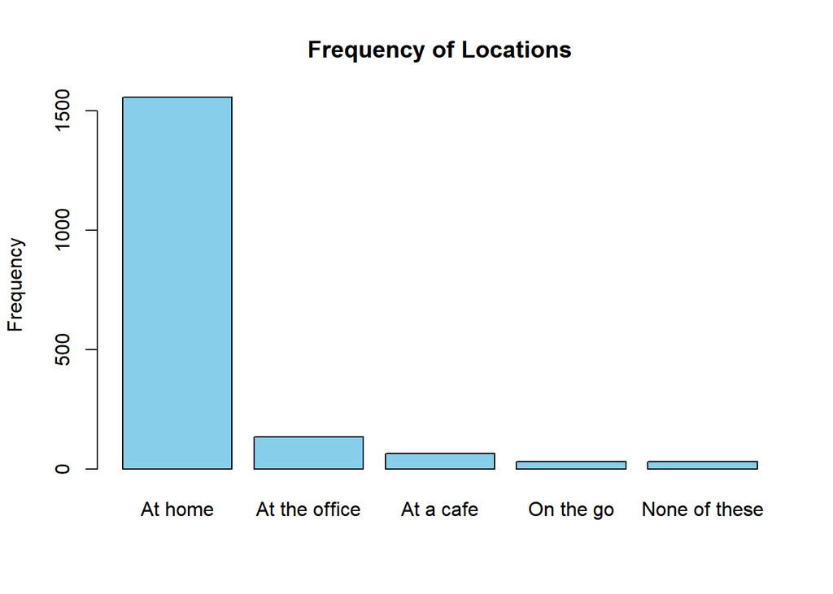

```r
sorted_counts <- loccounts[order(loccounts, decreasing = TRUE)]
sorted_locations <- locations[order(loccounts, decreasing = TRUE)]

barplot(sorted_counts, names.arg = sorted_locations, col = "skyblue", main = "Frequency of Locations", ylab = "Frequency") %>% +
  coord_flip()
```

Agar lebih menarik untuk visualisasi mari kita gunakan ggplot

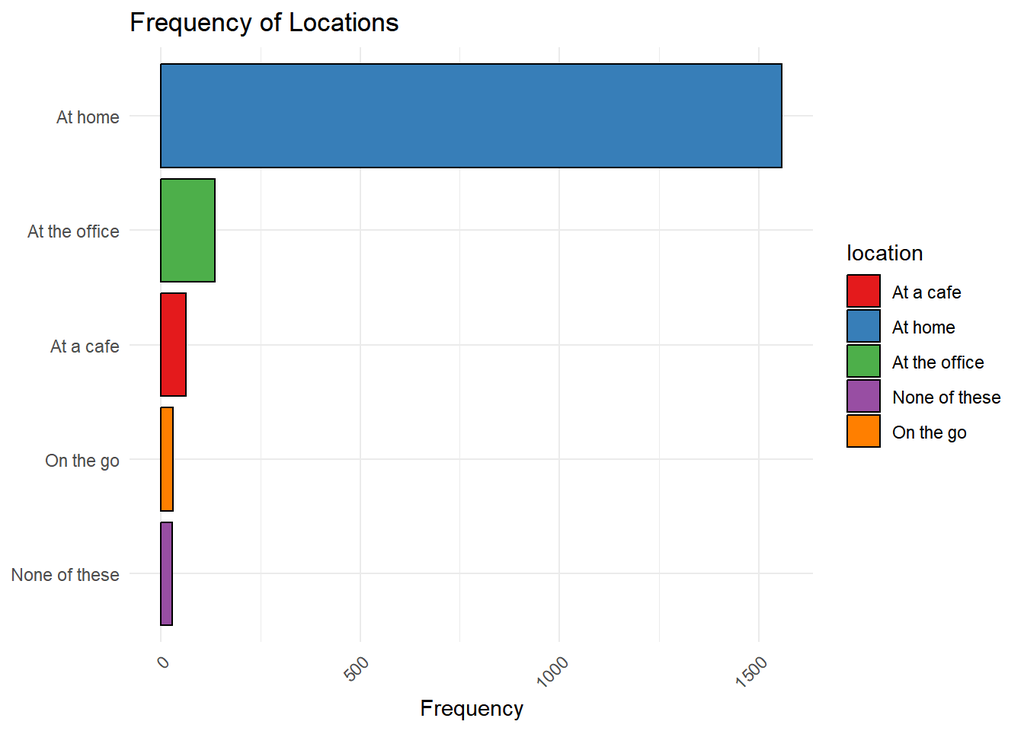

```r
plot_data <- data.frame(location = locations, count = loccounts)
plot_data <- plot_data[order(plot_data$count, decreasing = TRUE), ]

# Membuat plot menggunakan ggplot2
ggplot(plot_data, aes(x = reorder(location, count), y = count, fill = location)) +
  geom_bar(stat = "identity", color = "black") +
  labs(title = "Frequency of Locations", x = NULL, y = "Frequency") +
  theme_minimal() +
  theme(axis.text.x = element_text(angle = 45, hjust = 1)) +
  coord_flip()+
  scale_fill_brewer(palette = "Set1")
```

[figure not shown]

```r
ggplot(data = oage, aes(x = reorder(age, total, .desc = TRUE), y = total, fill = age)) +
  geom_bar(stat = "identity", color = "black") +
  labs(title = "Distribution of Top 5 Age Groups",
       x = NULL,
       y = "Count") +
  theme_minimal() +
  theme(axis.text.x = element_text(angle = 45, hjust = 1)) +
  coord_flip() +
  scale_fill_brewer(palette = "Set3")
```

Berdasarkan recipe yang ada berikut ini visualisasi penikmatnya berdasarkan umur

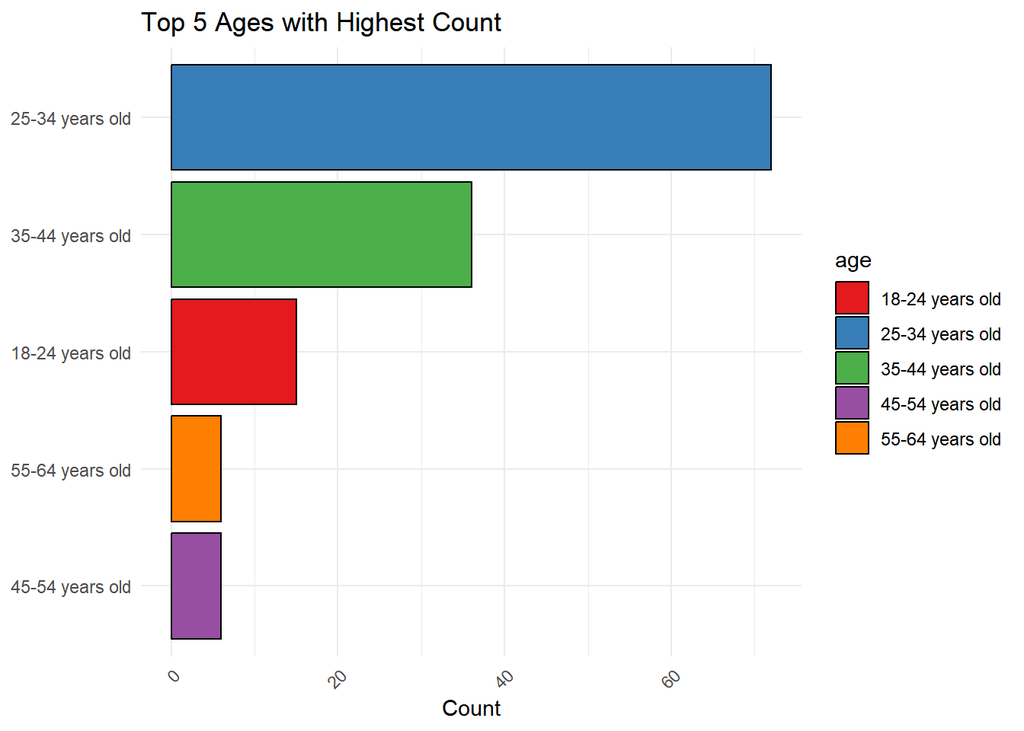

```r
ggplot(agerecipe, aes(x = reorder(age, count), y = count, fill = age)) +
  geom_col() +  geom_bar(stat = "identity", color = "black") +
  labs(title = "Top 5 Ages with Highest Count", x = NULL, y = "Count") +
  theme_minimal() +
  theme(axis.text.x = element_text(angle = 45, hjust = 1)) +
  scale_fill_brewer(palette = "Set1")+
  coord_flip()
```

*Berikut ini table resep terbaik*

|  | favorite | style | additions | strength | roast_level | caffeine | count |
| --- | --- | --- | --- | --- | --- | --- | --- |
| 1 | Pourover | Fruity | No - just black | Medium | Light | Full caffeine | 123 |
| 2 | Pourover | Fruity | No - just black | Somewhat strong | Light | Full caffeine | 118 |
| 3 | Pourover | Juicy | No - just black | Medium | Light | Full caffeine | 43 |
| 4 | Pourover | Juicy | No - just black | Somewhat strong | Light | Full caffeine | 42 |
| 5 | Pourover | Bright | No - just black | Somewhat strong | Light | Full caffeine | 34 |

Mari kita siapkan visualisasinya berdasarkan group recipe

```r
allrecipe <- allrecipe %>%
  mutate(group_recipe = paste0("Coffe Recipes", row_number()))
allrecipe
```

```
## # A tibble: 5 × 8
##   favorite style  additions     strength roast_level caffeine count group_recipe
##   <fct>    <fct>  <fct>         <fct>    <fct>       <fct>    <int> <chr>
## 1 Pourover Fruity No - just bl… Medium   Light       Full ca…   123 Coffe Recip…
## 2 Pourover Fruity No - just bl… Somewha… Light       Full ca…   118 Coffe Recip…
## 3 Pourover Juicy  No - just bl… Medium   Light       Full ca…    43 Coffe Recip…
## 4 Pourover Juicy  No - just bl… Somewha… Light       Full ca…    42 Coffe Recip…
## 5 Pourover Bright No - just bl… Somewha… Light       Full ca…    34 Coffe Recip…
```

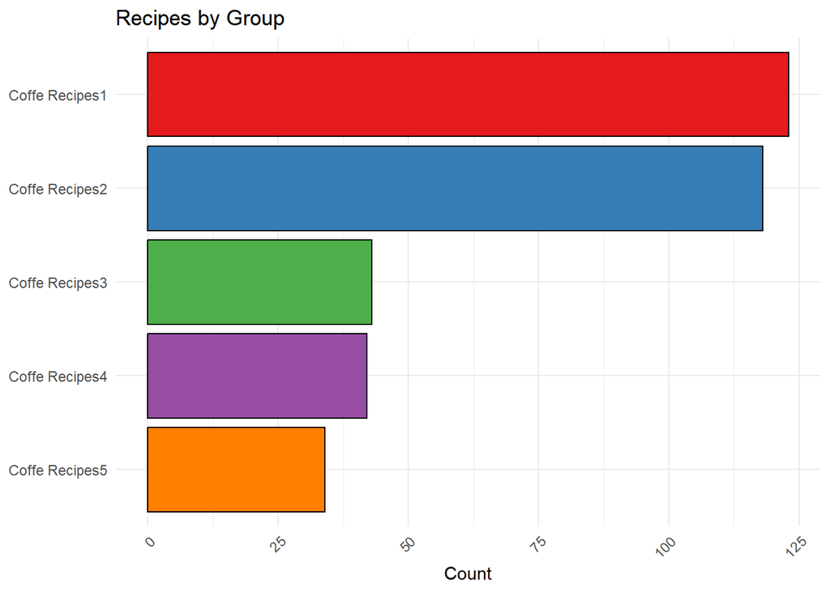

```r
ggplot(allrecipe, aes(x = reorder(group_recipe, count), y = count, fill = group_recipe)) +
  geom_col(color = "black") +  # Menggunakan geom_col() untuk bar warna fill
  labs(x = NULL, y = "Count", title = "Recipes by Group") +
  scale_fill_brewer(palette = "Set1") +
  theme_minimal() +
  theme(axis.text.x = element_text(angle = 45, hjust = 1),
        legend.position = "none") +  # Menghapus legend
  coord_flip()
```

## 5. Conclusion

Dari data diatas dapat kita simpulkan beberapa hal. Pertama konsumsi coffe tertinggi berada pada umur 25 - 34 tahun. Resep terbaik yaitu Pourover + Fruity + No - Just black + Medium + Light + Full caffeine, selain itu ada 4 lagi resep yang bisa kita rekomendasikan untuk dinikmati. Kita juga dapat menikmati coffe di tempat terbaik berdasarkan data diatas yaitu dirumah dengan 1558 responden yang memilih rumah sebagai tempat terbaiknya

## 6. Table

[output not shown]

[output cut: 4032 more lines]